# Module 5 Project

Gitin

10/13/2021

### Introduction

The regulation of temperature on the inside and surface of the body is essential to ensure proper functioning of bodily systems. Physical activity increases metabolism and blood flow in order to speed up the delivery of oxygen throughout the body and working muscles generate heat which leads to an increase in body temperature. In a study conducted on physical activity and sport, thermal imaging was used to evaluate the surface temperature of athletes. It was determined that a physiological advantage of training increases the ability to remove heat from the body, demonstrating a positive correlation between body temperature and physical activity.

### Methods

Subjects axillary temperatures were recorded in two different scenarios. First, their temperature was recorded for one hundred seconds sitting on a couch. Next, the subjects performed jumping jacks for five minutes, and their temperature was recorded for another one hundred seconds. The data was then condensed into a boxplot showing auxillary temperature versus the activity performed.

### Results

[output not shown]

[output cut: 40 more lines]

[output not shown]

```
## # A tibble: 6 x 4
##      ms  degC who     activity
##   <dbl> <dbl> <chr>   <chr>
## 1  6067  32   belinda active
## 2  8089  32.3 belinda active
## 3 10114  32.4 belinda active
## 4 12136  32.6 belinda active
## 5 14158  32.8 belinda active
## 6 16182  32.9 belinda active
```

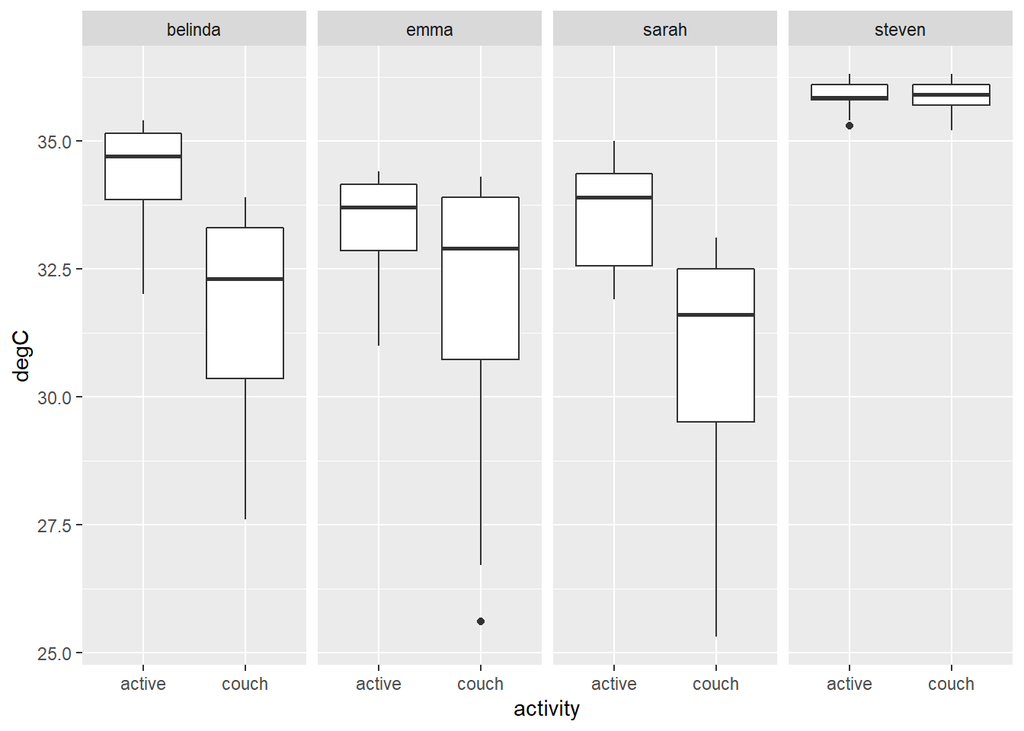

Boxplot of axillary temperature versus the activity performed.

### References

Chudecka, Monika. “Use of thermal imaging in the evaluation of body surface temperature in various physiological states in patients with different body compositions and varying levels of physical activity.” Central european journal of sport sciences and medicine 1.2 (2013).